# Veterinary Clinic Opening Hours Analysis

## 3. Weekend Hours

Total Open Hours During Weekends

| Mean | Median | Min | Max | Clinics_Open | Percent_Open |
| --- | --- | --- | --- | --- | --- |
| 5.9 | 4 | 0 | 48 | 19330 | 64.9 |

On average, clinics are open **5.9 hours on weekends**, with a median of **4 hours**. The range spans from **0 to 48 hours on weekends**. **64.9% of clinics** are open at some point during weekends (more than 0 hours in this category).

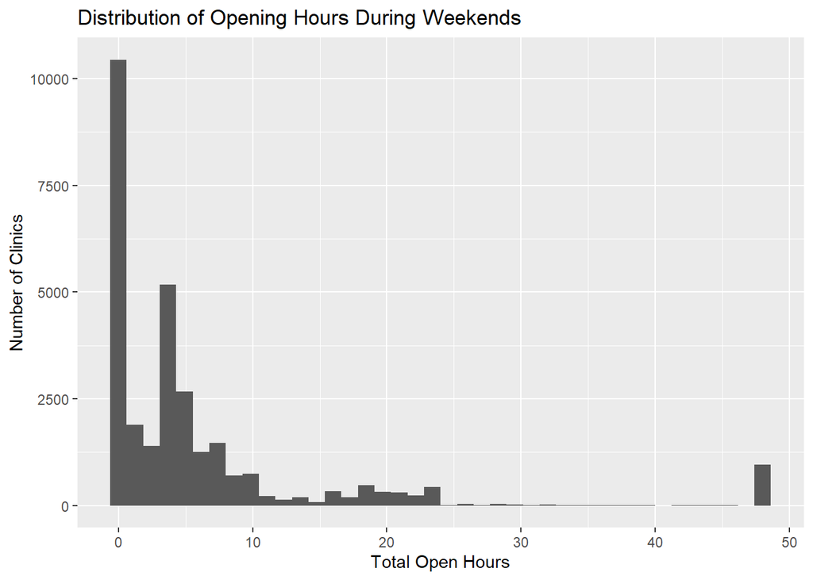

## 4. 24-Hour Operations

**1158 clinics, which are 3.9% of all clinics** operate 24 hours on at least one day per week. 962 clinics are open 24 hours on both Saturday and Sunday 24-hours, and 0 clinics are open ONLY on the weekend (Sat and Sun) and not at all during the week.

The following are the total number of clinics that have at least one 24-hour open during the week, the percent of all clinics this represents, and the total number of 24HR days across all clinics. Then the same for weekend 24-hour openings.

| Open_24HR_Week | Percent_Week | Num_24HR_Days_Open_Week | Open_24HR_Weekend | Percent_Weekend | Num_24HR_Days_Open_Weekend |
| --- | --- | --- | --- | --- | --- |
| 1036 | 3.5% | 4654 | 1101 | 3.7% | 2063 |

## 5. Overnight Availability (9pm–7am)

Total Open Hours 9pm - 7 am

| Mean | Median | Min | Max | Clinics_Open | Percent_Open |
| --- | --- | --- | --- | --- | --- |
| 0.1 | 0 | 0 | 28 | 378 | 1.3 |

When considering only the 1.3% of clinics that were open at some point overnight, these are the descriptive statistics and total hours:

Total Open Hours Overnight (9pm-7am) only where these hours > 0

| Mean | Median | Min | Max | Clinics_Open |
| --- | --- | --- | --- | --- |
| 5.7 | 5 | 1 | 28 | 378 |

## Summary Table (Averages)

[output not shown]

## Description of new columns added to the data file

- *clinic_id*: a unique clinic identifier created by joining the company name, city, state, and phone number.
- *total_hours*: the total opening hours of the clinic at any time and day.
- *total_hours_weekdays*: total opening hours Mon-Fri.
- *total_normal_biz_hours*: total opening hours Mon-Fri, 7 am-6 pm.
- *total_after_6pm_weekday*: total opening hours Mon-Fri, after 6 pm.
- *total_weekend_hours*: total opening hours Sat-Sun.
- *days_24hr_week*: the number of 24hr days a clinic is open during weekdays (0 to 5).
- *days_24hr_weekend*: the number of 24hr days a clinic is open during weekends (0 to 2).
- *total_9pm_7am_hours*: total opening hours after 9 pm and before 7 am at any day.
- *total_closed_days*: the number of days the clinic is closed.
- *any_overnight_flag*: a binary indicator of whether the clinic has any overnight (9 pm - 7 am) opening hours.
- *any_24hr_flag*: a binary indicator of whether the clinic has any 24hr days.